# NYCFlights: Arrival Delay Regression Model (Open Ended Variation)

Dennis Raj

April 18, 2017

# NYCFlights Model

Using the rectangular data that you created last week create a model for `arr_delay`. Follow a well defined process for creating a model as discussed in class or from one of the readings.

Break the process down into steps and create a codeblock for each step. - Use as many steps you feel as necessary - Concisely explain each step - Show all work

(You can start with the data that you created last week.)

## Step 1: Import Data & Setup Libraries

```r
#load libraries
library(dplyr)
```

```r
library(magrittr)
library(readr)
library(ggplot2)
# make sure flights_final.csv is in the current working directory, if not use Rstudio or setwd()
# set the working directory to read in the csv
flights <- tbl_df(read_csv("flights_final.csv", col_names = TRUE))
#double check the structure of flights
glimpse(flights)
```

```
## Observations: 336,776
## Variables: 48
## $ X1             <int> 1, 2, 3, 4, 5, 6, 7, 8, 9, 10, 11, 12, 13, 14, ...
## $ year.x         <int> 2013, 2013, 2013, 2013, 2013, 2013, 2013, 2013,...
## $ month.x        <int> 1, 1, 1, 1, 1, 1, 1, 1, 1, 1, 1, 1, 1, 1, 1, 1,...
## $ day.x          <int> 1, 1, 1, 1, 1, 1, 1, 1, 1, 1, 1, 1, 1, 1, 1, 1,...
## $ dep_time       <int> 517, 533, 542, 544, 554, 554, 555, 557, 557, 55...
## $ sched_dep_time <int> 515, 529, 540, 545, 600, 558, 600, 600, 600, 60...
## $ dep_delay      <int> 2, 4, 2, -1, -6, -4, -5, -3, -3, -2, -2, -2, -2...
## $ arr_time       <int> 830, 850, 923, 1004, 812, 740, 913, 709, 838, 7...
## $ sched_arr_time <int> 819, 830, 850, 1022, 837, 728, 854, 723, 846, 7...
## $ arr_delay      <int> 11, 20, 33, -18, -25, 12, 19, -14, -8, 8, -2, -...
## $ carrier        <chr> "UA", "UA", "AA", "B6", "DL", "UA", "B6", "EV",...
## $ flight         <int> 1545, 1714, 1141, 725, 461, 1696, 507, 5708, 79...
## $ tailnum        <chr> "N14228", "N24211", "N619AA", "N804JB", "N668DN...
```

[output cut: 35 more lines]

## Step 2: Prep the data

```r
# remove NA from flights$arr_delay
flights_clean <- flights %>% filter(!is.na(arr_delay)) %>% arrange(desc(arr_delay))

# count the NA values in arr_delay
sum(is.na(flights$arr_delay))
```

```
## [1] 9430
```

```r
# remove the row names row that was imported from the dataset
flights_clean <- flights_clean[2:length(flights_clean)]

# check the top and the bottom of the cleaned data set
head(flights_clean$arr_delay)
```

```
## [1] 1272 1127 1109 1007  989  931
```

```r
tail(flights_clean$arr_delay)
```

```
## [1] -73 -74 -75 -75 -79 -86
```

With the data cleaned, we can start to visualize the data.

## Step 3: Visual Exploration

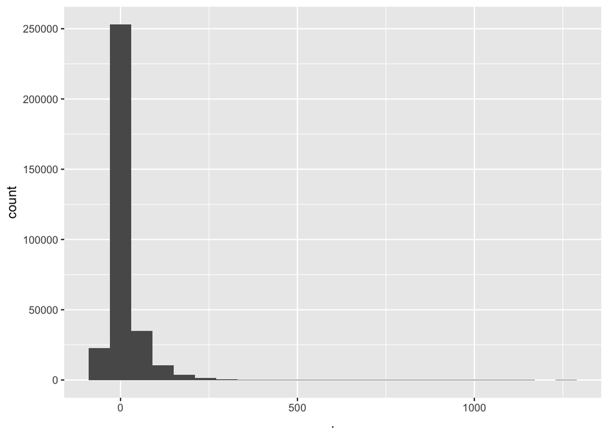

```r
# visualize the dependent variable (arrival delays)
# bin width set to 60 minutes arbitrarily to represent hours
flights_clean$arr_delay %>% qplot( , binwidth = 60)
```

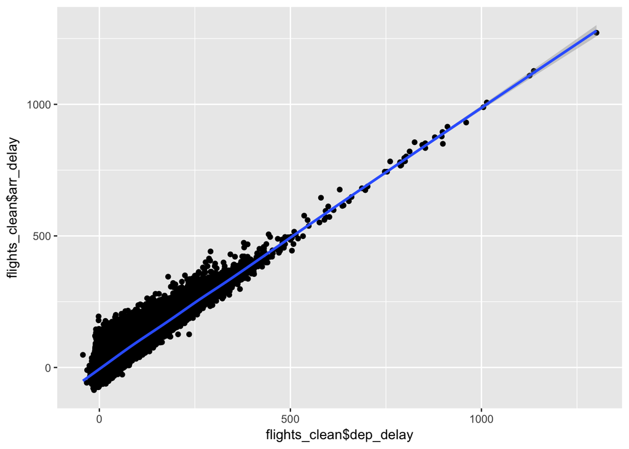

```r
# plot potential predictors, quick and dirty

qplot(y=flights_clean$arr_delay, x= flights_clean$dep_delay) + geom_smooth()
```

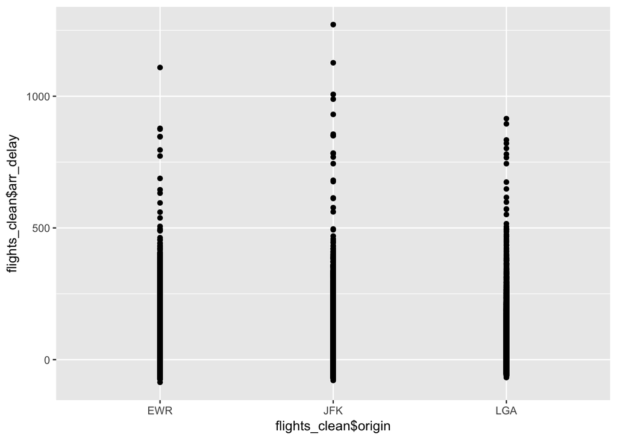

```r
qplot(y=flights_clean$arr_delay, x= flights_clean$origin) + geom_smooth()
```

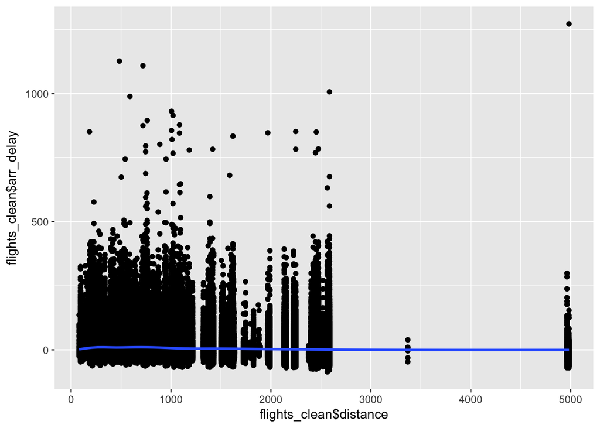

```r
qplot(y=flights_clean$arr_delay, x= flights_clean$distance) + geom_smooth()
```

It appears that our arrival delays have a right skew, indicating the presence of some outliers of large arrival delay values. We also have missing values (NA) in the arrival delay column, so we know that we need to clean the data before applying it.

## Step 4: Naive Model

```r
# develop a naive model based on the average (mean) of arrival delays
arr_delay_mean <- flights_clean$arr_delay %>% mean()

# add a new column for arrival delay mean to the original
flights_clean$arr_delay_mean <- arr_delay_mean

# create a new data frame from the original flights_clean
naive.rmse  <- flights_clean %>% select(arr_delay, arr_delay_mean)

# calculate a new column from the difference between arrival delay and mean arrival delay
naive.rmse$mean_distance <- naive.rmse$arr_delay - naive.rmse$arr_delay_mean

# calculate the RMSE from the new data frame
naive_rmse <- naive.rmse$mean_distance %>% .^2 %>% mean %>% sqrt
print(naive_rmse)
```

```
## [1] 44.63322
```

The RSME of Naive model is 44.63.

## Step 5: Create a training sample

```r
# create a sample data set for building the model, selecting only the needed columns
sample_flights <- flights_clean %>%
              select(arr_delay, month.x, dep_delay, carrier, origin, dest, air_time, distance,
                     engine, wind_speed, pressure, temp, visib) %>%
                      sample_n(1000)
```

## Step 6: Build a model

```r
# create a sample fit to review the potential linear regression
fit <- sample_flights %>% lm(formula = arr_delay ~ . )
summary(fit)
```

```
##
## Call:
## lm(formula = arr_delay ~ ., data = .)
##
## Residuals:
##     Min      1Q  Median      3Q     Max
## -30.212  -7.938  -0.770   6.213  89.604
##
## Coefficients:
##                    Estimate Std. Error t value Pr(>|t|)
## (Intercept)        20.09916   89.17553   0.225 0.821748
## month.x            -0.02458    0.16858  -0.146 0.884120
## dep_delay           1.01801    0.01591  63.975  < 2e-16 ***
## carrierAA           6.13573    4.05937   1.511 0.131148
## carrierAS          -6.27814   11.33008  -0.554 0.579693
## carrierB6          11.98995    3.10298   3.864 0.000123 ***
## carrierDL           5.15965    3.31270   1.558 0.119831
## carrierEV           4.93767    3.43831   1.436 0.151463
## carrierFL           8.02802    9.04396   0.888 0.375049
## carrierHA         -23.06895   13.20997  -1.746 0.081227 .
## carrierMQ           5.33904   11.61215   0.460 0.645828
## carrierOO          12.04862   14.96766   0.805 0.421128
## carrierUA           3.91006    3.78345   1.033 0.301772
## carrierUS          13.28665    4.26357   3.116 0.001912 **
## carrierVX           5.01495    5.45688   0.919 0.358430
## carrierWN           0.68520    4.83414   0.142 0.887328
## carrierYV          12.54219   14.69285   0.854 0.393628
## originJFK          -1.93785    2.56776  -0.755 0.450711
## originLGA           2.28992    2.51546   0.910 0.362983
## destATL            14.43821   73.63977   0.196 0.844620
## destAUS            -2.85264  172.05549  -0.017 0.986777
## destBDL            20.26714   15.88407   1.276 0.202433
## destBGR            11.95735   27.35709   0.437 0.662196
## destBHM             7.50920   88.53053   0.085 0.932430
## destBNA            14.24414   73.98686   0.193 0.847393
## destBOS            14.39087   10.35848   1.389 0.165223
## destBTV            13.79064   15.78586   0.874 0.382655
## destBUF             6.93904   16.76918   0.414 0.679159
## destBWI            17.49902   11.78040   1.485 0.137914
## destCHS            15.99385   58.18272   0.275 0.783488
```

[output cut: 63 more lines]

```
## distance           -0.11054    0.13031  -0.848 0.396571
## engineTurbo-fan    -2.70063    8.13771  -0.332 0.740098
## engineTurbo-jet     0.35144    8.26881   0.043 0.966111
## engineTurbo-shaft   6.36114   11.48664   0.554 0.579916
## wind_speed          0.01306    0.10009   0.131 0.896194
## pressure           -0.05596    0.08211  -0.681 0.495807
## temp                0.19516    0.03658   5.335 1.32e-07 ***
## visib              -1.30719    0.44458  -2.940 0.003396 **
## ---
## Signif. codes:  0 '***' 0.001 '**' 0.01 '*' 0.05 '.' 0.1 ' ' 1
##
## Residual standard error: 13.86 on 649 degrees of freedom
##   (250 observations deleted due to missingness)
## Multiple R-squared:  0.896,  Adjusted R-squared:   0.88
## F-statistic: 55.94 on 100 and 649 DF,  p-value: < 2.2e-16
```

```r
# create the full fit using likely predictors
fit_full <- flights_clean %>% select(arr_delay, dep_delay, origin, distance) %>%
                                                          lm(formula = arr_delay ~ .)
summary(fit_full)
```

```
##
## Call:
## lm(formula = arr_delay ~ ., data = .)
##
## Residuals:
##      Min       1Q   Median       3Q      Max
## -107.757  -11.001   -1.919    8.682  205.645
##
## Coefficients:
##               Estimate Std. Error  t value Pr(>|t|)
## (Intercept) -3.5938370  0.0716085  -50.187   <2e-16 ***
## dep_delay    1.0184775  0.0007832 1300.329   <2e-16 ***
## originJFK   -0.0038474  0.0760278   -0.051     0.96
## originLGA    0.8063035  0.0780392   10.332   <2e-16 ***
## distance    -0.0024283  0.0000442  -54.938   <2e-16 ***
## ---
## Signif. codes:  0 '***' 0.001 '**' 0.01 '*' 0.05 '.' 0.1 ' ' 1
##
## Residual standard error: 17.93 on 327341 degrees of freedom
## Multiple R-squared:  0.8387, Adjusted R-squared:  0.8387
## F-statistic: 4.255e+05 on 4 and 327341 DF,  p-value: < 2.2e-16
```

## Step 7: Evaluate the model

```r
# test the effectiveness of the model using RMSE
model1_rmse <- fit_full %>% resid %>% .^2 %>% mean %>% sqrt
print(model1_rmse)
```

```
## [1] 17.9258
```

The RMSE of our linear regression model is 17.9258

## Step 8: Attempt to improve performance

```r
# create a second model with more predictors included from the data set
fit_full2 <- flights_clean %>% select(arr_delay, month.x,
                                     dep_delay, carrier, origin, dest, air_time, distance, engine,
                                     wind_speed, pressure, temp, visib) %>%
                                                        lm(formula = arr_delay ~ . )
summary(fit_full2)
```

```
##
## Call:
## lm(formula = arr_delay ~ ., data = .)
##
## Residuals:
##     Min      1Q  Median      3Q     Max
## -55.560  -8.451  -1.607   6.258 168.877
##
## Coefficients:
##                       Estimate Std. Error  t value Pr(>|t|)
## (Intercept)          8.671e+01  1.279e+01    6.782 1.19e-11 ***
## month.x              3.477e-02  8.602e-03    4.042 5.31e-05 ***
## dep_delay            1.015e+00  7.316e-04 1386.723  < 2e-16 ***
## carrierAA            1.940e+00  2.227e-01    8.711  < 2e-16 ***
## carrierAS           -2.447e+00  6.413e-01   -3.816 0.000136 ***
## carrierB6            7.198e+00  1.524e-01   47.222  < 2e-16 ***
## carrierDL            2.090e+00  1.643e-01   12.720  < 2e-16 ***
## carrierEV            3.035e+00  1.603e-01   18.934  < 2e-16 ***
## carrierF9            7.728e+00  6.234e-01   12.395  < 2e-16 ***
## carrierFL            7.049e+00  3.749e-01   18.801  < 2e-16 ***
## carrierHA           -3.955e+00  1.106e+00   -3.576 0.000349 ***
## carrierMQ            6.190e+00  5.323e-01   11.627  < 2e-16 ***
## carrierOO            6.611e+00  2.638e+00    2.506 0.012199 *
## carrierUA            7.783e-01  1.887e-01    4.125 3.71e-05 ***
## carrierUS            7.363e+00  2.087e-01   35.275  < 2e-16 ***
## carrierVX           -2.596e+00  2.721e-01   -9.540  < 2e-16 ***
## carrierWN           -1.435e+00  2.475e-01   -5.799 6.67e-09 ***
## carrierYV            4.372e+00  6.500e-01    6.726 1.75e-11 ***
## originJFK           -1.105e+00  1.304e-01   -8.473  < 2e-16 ***
## originLGA            4.283e-01  1.254e-01    3.415 0.000637 ***
## destACK             -8.329e+01  1.071e+01   -7.778 7.37e-15 ***
## destALB             -8.298e+01  1.097e+01   -7.561 4.02e-14 ***
## destANC              9.978e+01  1.189e+01    8.392  < 2e-16 ***
## destATL             -4.698e+01  7.033e+00   -6.679 2.41e-11 ***
## destAUS             -1.430e+01  2.238e+00   -6.390 1.66e-10 ***
## destAVL             -5.521e+01  8.139e+00   -6.784 1.17e-11 ***
## destBDL             -8.457e+01  1.115e+01   -7.585 3.35e-14 ***
## destBGR             -6.744e+01  9.538e+00   -7.070 1.55e-12 ***
## destBHM             -4.728e+01  6.403e+00   -7.384 1.54e-13 ***
## destBNA             -5.244e+01  7.017e+00   -7.473 7.84e-14 ***
```

[output cut: 96 more lines]

```
## engineTurbo-fan     -1.320e+00  2.090e+00   -0.632 0.527625
## engineTurbo-jet      6.462e-01  2.092e+00    0.309 0.757437
## engineTurbo-prop     1.562e+00  2.979e+00    0.524 0.600105
## engineTurbo-shaft   -2.123e-01  2.208e+00   -0.096 0.923378
## wind_speed           4.436e-02  5.430e-03    8.169 3.13e-16 ***
## pressure            -2.086e-02  4.174e-03   -4.997 5.82e-07 ***
## temp                 1.839e-01  1.863e-03   98.720  < 2e-16 ***
## visib               -8.373e-01  2.464e-02  -33.983  < 2e-16 ***
## ---
## Signif. codes:  0 '***' 0.001 '**' 0.01 '*' 0.05 '.' 0.1 ' ' 1
##
## Residual standard error: 13.64 on 246894 degrees of freedom
##   (80318 observations deleted due to missingness)
## Multiple R-squared:  0.8959, Adjusted R-squared:  0.8958
## F-statistic: 1.597e+04 on 133 and 246894 DF,  p-value: < 2.2e-16
```

```r
# test the effectiveness of the model using RMSE
model2_rmse <- fit_full2 %>% resid %>% .^2 %>% mean %>% sqrt
print(model2_rmse)
```

```
## [1] 13.63759
```

Our second model got the RMSE down to 13.63759

# Question:

Is this a good model? (Write your answer here.)

The model is ok, given the simplicity of a linear regression analysis. We moved from a RMSE in our naive model of 44.633 to a simple linear regression of arrival delay and depature delay, origin and distance which decreased our RMSE to 17.9258 (Model 1), which is a significant gain over the naive model. When we added more factors into the regression (Model 2) we were able to reduce the RMSE to 13.6375, which is a pretty good gain over Model 1. I think future analysis could lead to a lower score by working with subject matter experts (Pilots, FAA analysts, Air Traffic Controllers) to determine what factors lead to a plane not being able to take off or land, which would lead to delays. Future analysis could also see if other ways to fit the data outside of simple linear regression would make sense, like quadratic, exponential or logrithmic.